# Build and deploy a stroke prediction model using R

Olapeju Esuola

April 25, 2024

# About Data Analysis Report

This RMarkdown file contains the report of the data analysis done for the project on building and deploying a stroke prediction model in R. It contains analysis such as data exploration, summary statistics and building the prediction models. The final report was completed on `April 25, 2024`.

**Data Description:**

According to the World Health Organization (WHO) stroke is the 2nd leading cause of death globally, responsible for approximately 11% of total deaths.

This data set is used to predict whether a patient is likely to get stroke based on the input parameters like gender, age, various diseases, and smoking status. Each row in the data provides relevant information about the patient.

Project Context

The escalating prevalence of strokes poses a significant challenge to healthcare systems worldwide. Recognizing the imperative for preemptive measures, our organization endeavors to harness advanced analytics and machine learning to predict stroke occurrences accurately. Through the integration of predictive models into clinical workflows, we aim to identify high-risk patients promptly and implement targeted preventive interventions.

Project Objectives

Exploratory Data Analysis (EDA): Investigate the dataset to discern critical patient and clinical attributes associated with stroke incidence. Model Development: Develop a validated stroke prediction model capable of informing clinical decision-making processes effectively. Model Deployment: Integrate the prediction model into the organization’s clinical infrastructure to enhance patient care and outcomes.

# Task One: Import data and data preprocessing

## Load data and install packages

```r
# Load required packages
#install.packages("tidyverse")  # Install tidyverse for data manipulation and visualization
#install.packages("skimr")      # Install skimr for summary statistics
#install.packages("ggplot2")    # Install ggplot2 for advanced data visualization

# Load the installed packages
library(tidyverse)
library(skimr)
library(ggplot2)

# Load the dataset
stroke_data <- read_csv("healthcare-dataset-stroke-data.csv")

# Display the first few rows of the dataset
head(stroke_data)
```

```
## # A tibble: 6 × 12
##      id gender   age hypertension heart_disease ever_married work_type
##   <dbl> <chr>  <dbl>        <dbl>         <dbl> <chr>        <chr>
## 1  9046 Male      67            0             1 Yes          Private
## 2 51676 Female    61            0             0 Yes          Self-employed
## 3 31112 Male      80            0             1 Yes          Private
## 4 60182 Female    49            0             0 Yes          Private
## 5  1665 Female    79            1             0 Yes          Self-employed
## 6 56669 Male      81            0             0 Yes          Private
## # ℹ 5 more variables: Residence_type <chr>, avg_glucose_level <dbl>, bmi <chr>,
## #   smoking_status <chr>, stroke <dbl>
```

```r
# Display data structure
str(stroke_data)
```

```
## spc_tbl_ [5,110 × 12] (S3: spec_tbl_df/tbl_df/tbl/data.frame)
##  $ id               : num [1:5110] 9046 51676 31112 60182 1665 ...
##  $ gender           : chr [1:5110] "Male" "Female" "Male" "Female" ...
##  $ age              : num [1:5110] 67 61 80 49 79 81 74 69 59 78 ...
##  $ hypertension     : num [1:5110] 0 0 0 0 1 0 1 0 0 0 ...
##  $ heart_disease    : num [1:5110] 1 0 1 0 0 0 1 0 0 0 ...
##  $ ever_married     : chr [1:5110] "Yes" "Yes" "Yes" "Yes" ...
##  $ work_type        : chr [1:5110] "Private" "Self-employed" "Private" "Private" ...
##  $ Residence_type   : chr [1:5110] "Urban" "Rural" "Rural" "Urban" ...
##  $ avg_glucose_level: num [1:5110] 229 202 106 171 174 ...
##  $ bmi              : chr [1:5110] "36.6" "N/A" "32.5" "34.4" ...
##  $ smoking_status   : chr [1:5110] "formerly smoked" "never smoked" "never smoked" "smokes" ...
##  $ stroke           : num [1:5110] 1 1 1 1 1 1 1 1 1 1 ...
##  - attr(*, "spec")=
##   .. cols(
##   ..   id = col_double(),
##   ..   gender = col_character(),
##   ..   age = col_double(),
##   ..   hypertension = col_double(),
##   ..   heart_disease = col_double(),
##   ..   ever_married = col_character(),
##   ..   work_type = col_character(),
##   ..   Residence_type = col_character(),
##   ..   avg_glucose_level = col_double(),
##   ..   bmi = col_character(),
##   ..   smoking_status = col_character(),
##   ..   stroke = col_double()
##   .. )
##  - attr(*, "problems")=<externalptr>
```

```r
# Convert BMI from character to numeric
stroke_data$bmi <- as.numeric(stroke_data$bmi)

# Drop rows with 'N/A' values in BMI
stroke_data <- stroke_data[!is.na(stroke_data$bmi), ]

# Count occurrences of "N/A" in each column
# na_counts <- sapply(stroke_data, function(x) sum(x == "N/A", na.rm = TRUE))

# Print the counts of "N/A" in each column
# na_counts
```

Based on the information provided after loading the dataset and examining the first few rows using the head() function, here is the description of the dataset:

ID: Unique identifier for each observation. Gender: Categorical variable indicating the gender of the individual. Age: Numerical variable representing the age of the individual. Hypertension: Binary variable (0 or 1) indicating whether the individual has hypertension. Heart Disease: Binary variable (0 or 1) indicating whether the individual has heart disease. Ever Married: Categorical variable indicating whether the individual is married. Work Type: Categorical variable representing the type of work the individual is engaged in. Residence Type: Categorical variable indicating whether the individual resides in an urban or rural area. Average Glucose Level: Numerical variable representing the average glucose level of the individual. BMI: Body Mass Index of the individual. Smoking Status: Categorical variable indicating the smoking status of the individual. Stroke: Binary variable (0 or 1) indicating whether the individual had a stroke.

After conducting a thorough analysis of the dataset’s structure, I discovered that the BMI column contained “N/A” values, representing missing values. To address this issue, I first converted the BMI column from character to numeric. Then, I proceeded to drop rows containing “N/A” values in the BMI column. Furthermore, I performed a check on the entire dataset to identify similar situations, and it appears that the dataset is now clean from missing values.

## Describe and explore the data

```r
# Display data summary
skim(stroke_data)
```

Data summary

| Name | stroke_data |
| --- | --- |
| Number of rows | 4909 |
| Number of columns | 12 |
| _______________________ |  |
| Column type frequency: |  |
| character | 5 |
| numeric | 7 |
| ________________________ |  |
| Group variables | None |

**Variable type: character**

| skim_variable | n_missing | complete_rate | min | max | empty | n_unique | whitespace |
| --- | --- | --- | --- | --- | --- | --- | --- |
| gender | 0 | 1 | 4 | 6 | 0 | 3 | 0 |
| ever_married | 0 | 1 | 2 | 3 | 0 | 2 | 0 |
| work_type | 0 | 1 | 7 | 13 | 0 | 5 | 0 |
| Residence_type | 0 | 1 | 5 | 5 | 0 | 2 | 0 |
| smoking_status | 0 | 1 | 6 | 15 | 0 | 4 | 0 |

**Variable type: numeric**

| skim_variable | n_missing | complete_rate | mean | sd | p0 | p25 | p50 | p75 | p100 | hist |
| --- | --- | --- | --- | --- | --- | --- | --- | --- | --- | --- |
| id | 0 | 1 | 37064.31 | 20995.10 | 77.00 | 18605.00 | 37608.00 | 55220.00 | 72940.00 | ▇▇▇▇▇ |
| age | 0 | 1 | 42.87 | 22.56 | 0.08 | 25.00 | 44.00 | 60.00 | 82.00 | ▅▆▇▇▆ |
| hypertension | 0 | 1 | 0.09 | 0.29 | 0.00 | 0.00 | 0.00 | 0.00 | 1.00 | ▇▁▁▁▁ |
| heart_disease | 0 | 1 | 0.05 | 0.22 | 0.00 | 0.00 | 0.00 | 0.00 | 1.00 | ▇▁▁▁▁ |
| avg_glucose_level | 0 | 1 | 105.31 | 44.42 | 55.12 | 77.07 | 91.68 | 113.57 | 271.74 | ▇▃▁▁▁ |
| bmi | 0 | 1 | 28.89 | 7.85 | 10.30 | 23.50 | 28.10 | 33.10 | 97.60 | ▇▇▁▁▁ |
| stroke | 0 | 1 | 0.04 | 0.20 | 0.00 | 0.00 | 0.00 | 0.00 | 1.00 | ▇▁▁▁▁ |

```r
# Summary statistics
summary(stroke_data)
```

```
##        id           gender               age         hypertension
##  Min.   :   77   Length:4909        Min.   : 0.08   Min.   :0.00000
##  1st Qu.:18605   Class :character   1st Qu.:25.00   1st Qu.:0.00000
##  Median :37608   Mode  :character   Median :44.00   Median :0.00000
##  Mean   :37064                      Mean   :42.87   Mean   :0.09187
##  3rd Qu.:55220                      3rd Qu.:60.00   3rd Qu.:0.00000
##  Max.   :72940                      Max.   :82.00   Max.   :1.00000
##  heart_disease    ever_married        work_type         Residence_type
##  Min.   :0.0000   Length:4909        Length:4909        Length:4909
##  1st Qu.:0.0000   Class :character   Class :character   Class :character
##  Median :0.0000   Mode  :character   Mode  :character   Mode  :character
##  Mean   :0.0495
##  3rd Qu.:0.0000
##  Max.   :1.0000
##  avg_glucose_level      bmi        smoking_status         stroke
##  Min.   : 55.12    Min.   :10.30   Length:4909        Min.   :0.00000
##  1st Qu.: 77.07    1st Qu.:23.50   Class :character   1st Qu.:0.00000
##  Median : 91.68    Median :28.10   Mode  :character   Median :0.00000
##  Mean   :105.31    Mean   :28.89                      Mean   :0.04257
##  3rd Qu.:113.57    3rd Qu.:33.10                      3rd Qu.:0.00000
##  Max.   :271.74    Max.   :97.60                      Max.   :1.00000
```

Findings: Based on the information obtained after deploying the skim() and summary() functions, the dataset appears to be clean, with no missing values or abnormalities detected. To delve deeper into the analysis, I will proceed by visualizing both the categorical and numerical variables. Additionally, I will check the summary statistics for the numerical variables and the frequency for the categorical variables.

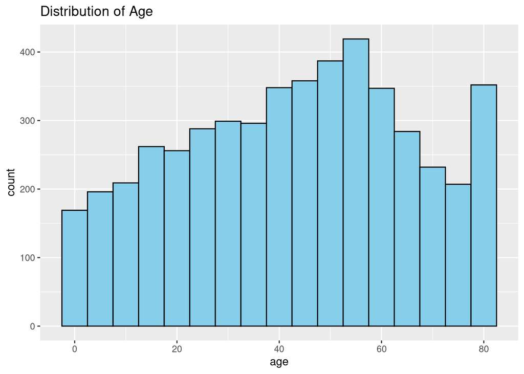

```r
# Histogram of Age
ggplot(stroke_data, aes(x = age)) +
  geom_histogram(binwidth = 5, fill = "skyblue", color = "black") +
  labs(title = "Distribution of Age")
```

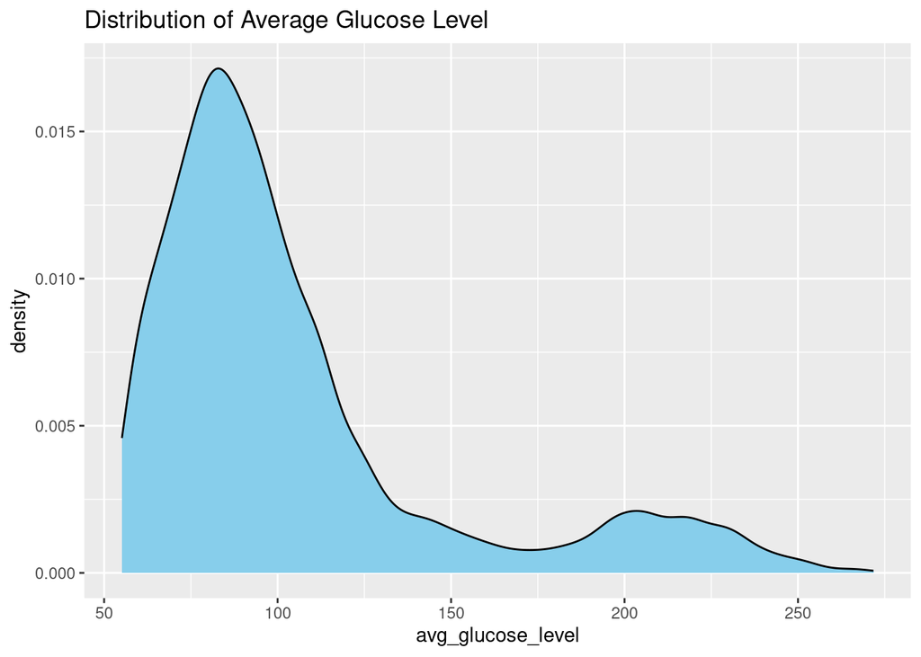

```r
# Density plot of Average Glucose Level
ggplot(stroke_data, aes(x = avg_glucose_level)) +
  geom_density(fill = "skyblue", color = "black") +
  labs(title = "Distribution of Average Glucose Level")
```

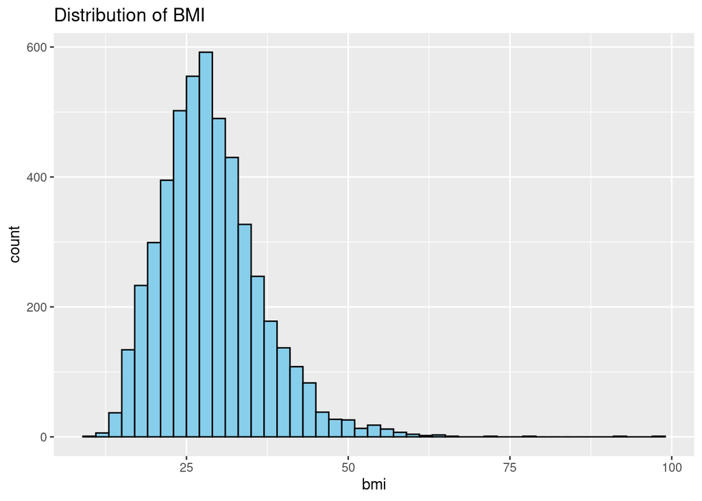

```r
# Histogram of BMI
ggplot(stroke_data, aes(x = bmi)) +
  geom_histogram(binwidth = 2, fill = "skyblue", color = "black") +
  labs(title = "Distribution of BMI")
```

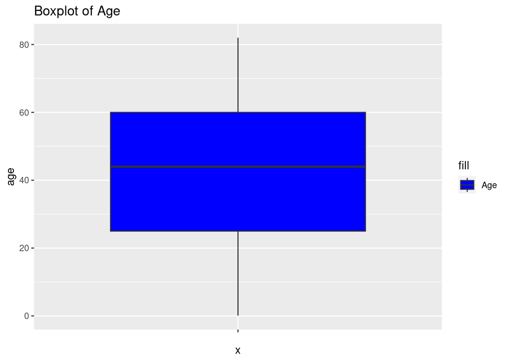

```r
# Visualize boxplots for numerical variables with color
library(ggplot2)
ggplot(stroke_data, aes(x = "", y = age, fill = "Age")) +
  geom_boxplot() +
  labs(title = "Boxplot of Age") +
  scale_fill_manual(values = "blue")
```

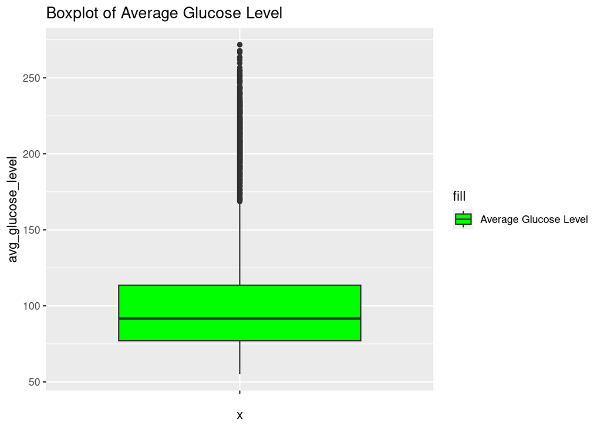

```r
ggplot(stroke_data, aes(x = "", y = avg_glucose_level, fill = "Average Glucose Level")) +
  geom_boxplot() +
  labs(title = "Boxplot of Average Glucose Level") +
  scale_fill_manual(values = "green")
```

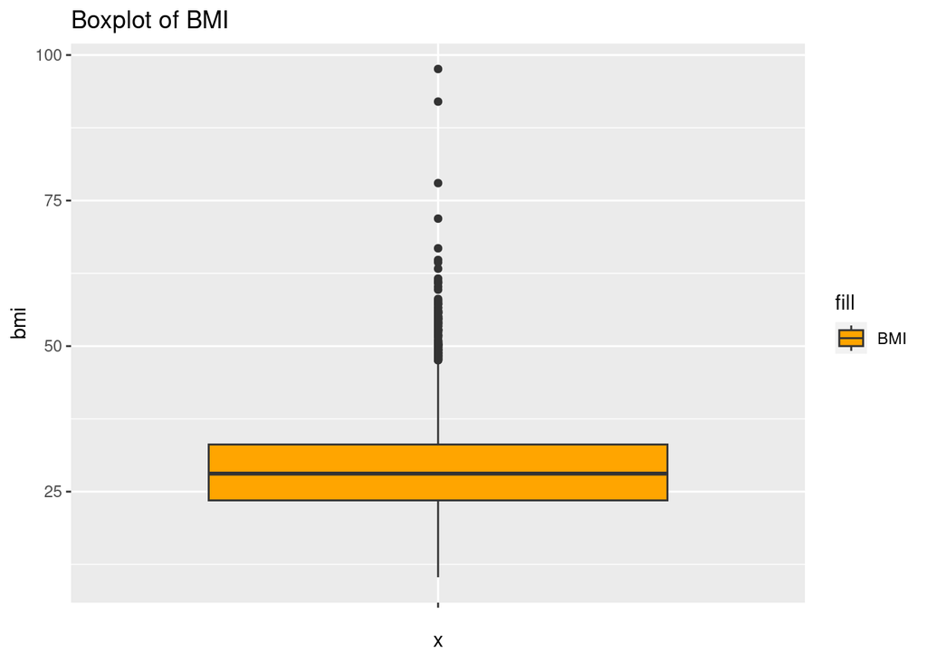

```r
ggplot(stroke_data, aes(x = "", y = bmi, fill = "BMI")) +
  geom_boxplot() +
  labs(title = "Boxplot of BMI") +
  scale_fill_manual(values = "orange")
```

After employing boxplots to detect outliers, it was observed that both the BMI and glucose level variables contain outliers. Given that BMI and glucose levels are physiological measures that can naturally exhibit wide variation among individuals, I have decided not to treat these outliers. This decision is based on the understanding that outliers in these variables may represent genuine data points and removing them could potentially lead to the loss of valuable information. Therefore, I will proceed with the analysis without outlier treatment for the BMI and glucose level variables.

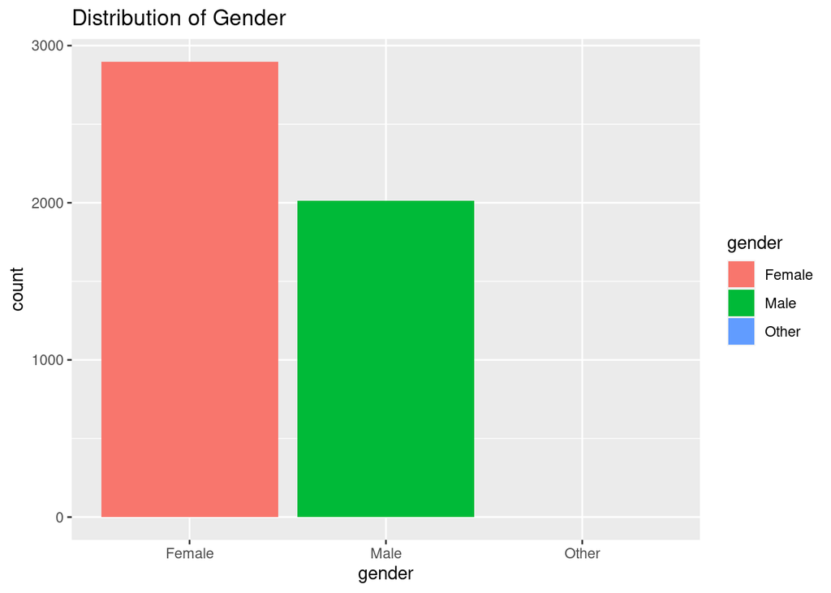

```r
# Distribution of Gender
library(ggplot2)
ggplot(stroke_data, aes(x = gender, fill = gender)) +
  geom_bar() +
  labs(title = "Distribution of Gender")
```

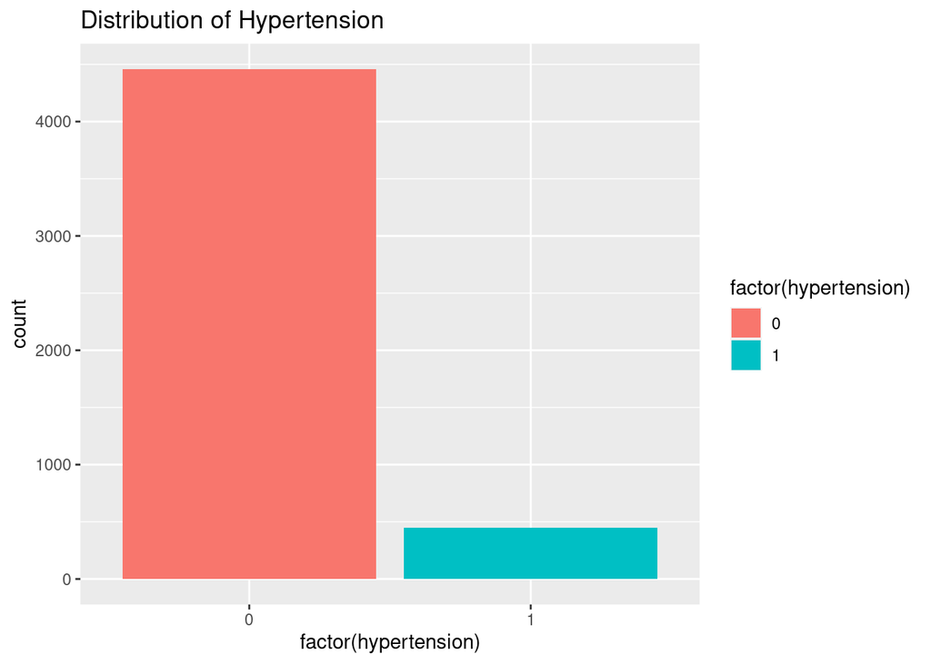

```r
# Distribution of Hypertension
ggplot(stroke_data, aes(x = factor(hypertension), fill = factor(hypertension))) +
  geom_bar() +
  labs(title = "Distribution of Hypertension")
```

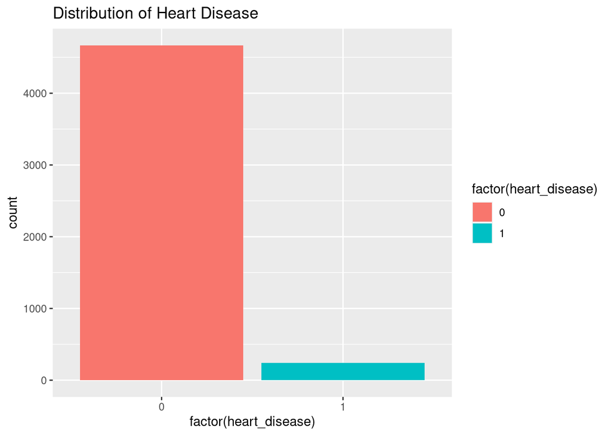

```r
# Distribution of Heart Disease
ggplot(stroke_data, aes(x = factor(heart_disease), fill = factor(heart_disease))) +
  geom_bar() +
  labs(title = "Distribution of Heart Disease")
```

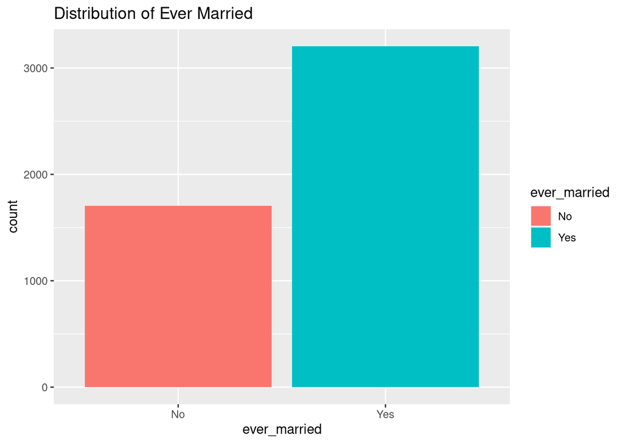

```r
# Distribution of Ever Married
ggplot(stroke_data, aes(x = ever_married, fill = ever_married)) +
  geom_bar() +
  labs(title = "Distribution of Ever Married")
```

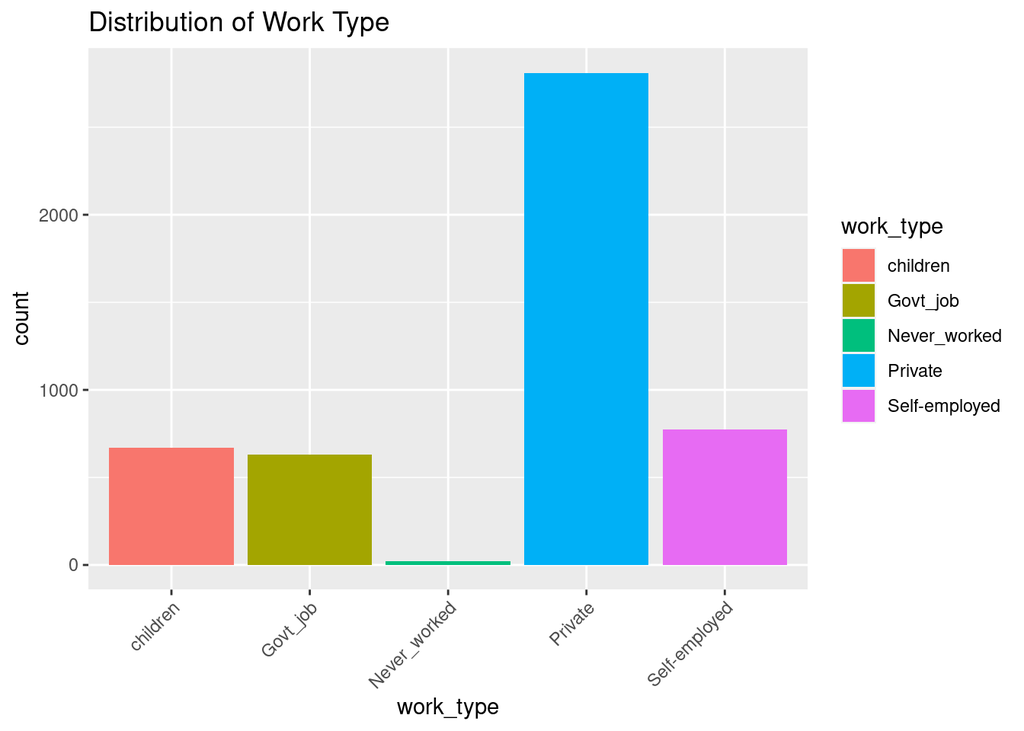

```r
# Distribution of Work Type
ggplot(stroke_data, aes(x = work_type, fill = work_type)) +
  geom_bar() +
  labs(title = "Distribution of Work Type") +
  theme(axis.text.x = element_text(angle = 45, hjust = 1))
```

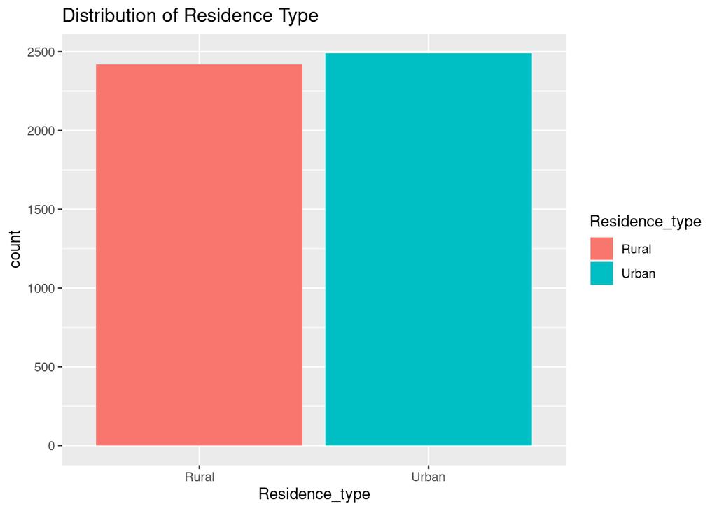

```r
# Distribution of Residence Type
ggplot(stroke_data, aes(x = Residence_type, fill = Residence_type)) +
  geom_bar() +
  labs(title = "Distribution of Residence Type")
```

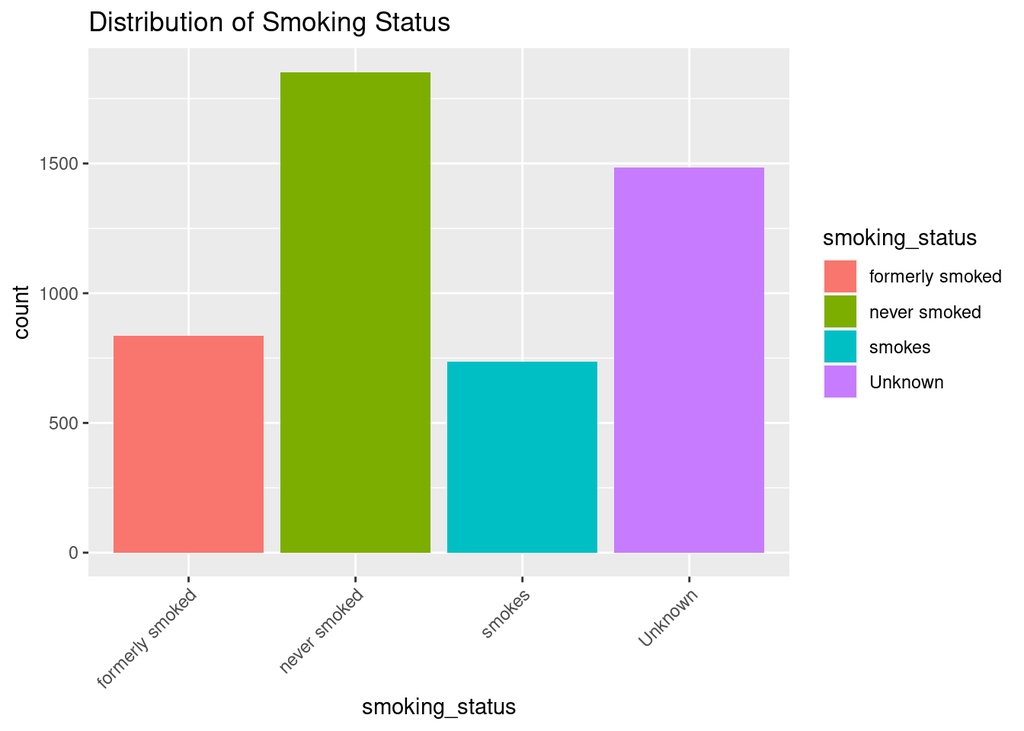

```r
# Distribution of Smoking Status
ggplot(stroke_data, aes(x = smoking_status, fill = smoking_status)) +
  geom_bar() +
  labs(title = "Distribution of Smoking Status") +
  theme(axis.text.x = element_text(angle = 45, hjust = 1))
```

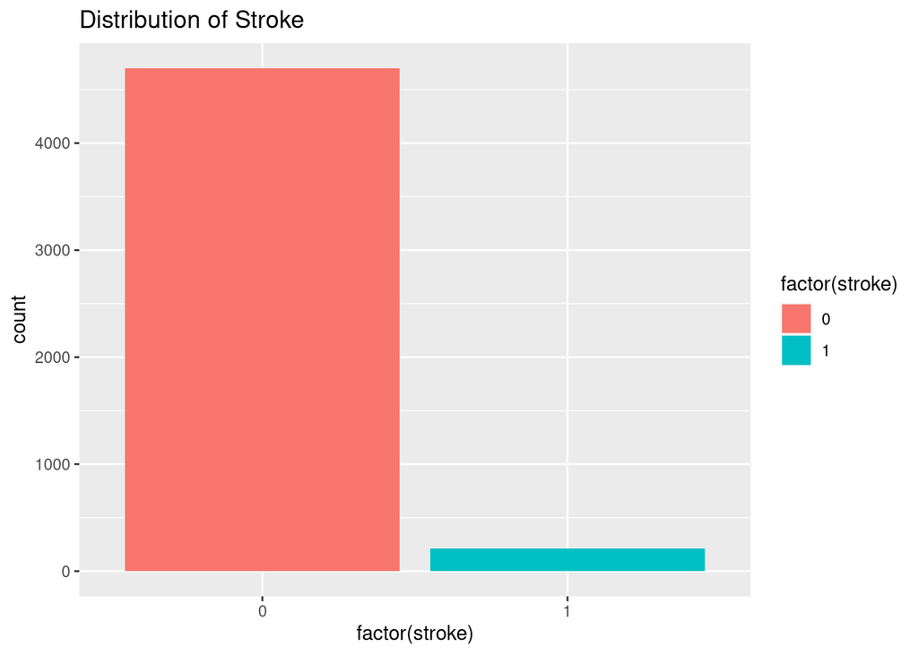

```r
# Distribution of Stroke
ggplot(stroke_data, aes(x = factor(stroke), fill = factor(stroke))) +
  geom_bar() +
  labs(title = "Distribution of Stroke")
```

The dataset reveals a notable prevalence of certain characteristics: a higher representation of females, individuals without hypertension or heart disease, married individuals, those with a private work class, urban residents slightly outnumbering rural residents, individuals who have never smoked, and a majority of individuals without a history of stroke.

During my data visualization exploration, I observed that a significant number of individuals did not provide information under the smoking_status column, and it was recorded as “Unknown.” Recognizing the importance of this variable and since I have a large dataset, I have decided to convert “Unknown” values to “NA” and drop rows with missing values.

```r
library(dplyr)

# Convert "unknown" values to NA in smoking_status
stroke_data <- stroke_data %>%
  mutate(smoking_status = na_if(smoking_status, "Unknown"))
# Remove rows with missing values
stroke_data <- na.omit(stroke_data)
# Check for missing data
colSums(is.na(stroke_data))
```

```
##                id            gender               age      hypertension
##                 0                 0                 0                 0
##     heart_disease      ever_married         work_type    Residence_type
##                 0                 0                 0                 0
## avg_glucose_level               bmi    smoking_status            stroke
##                 0                 0                 0                 0
```

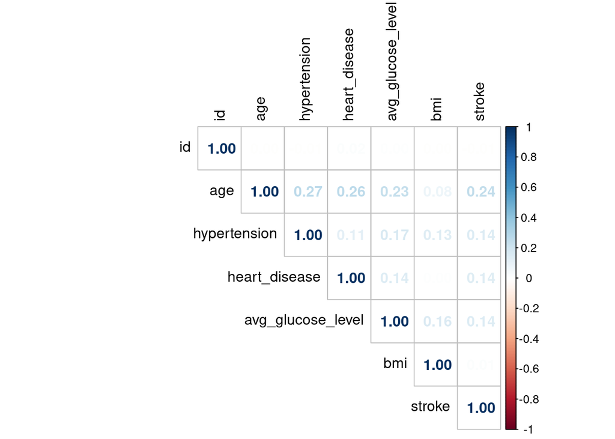

```r
# Assessing the relationship between numeric independent variables and dependent variable
# Install and load the corrplot package
#install.packages("corrplot")
library(corrplot)

# Compute correlation matrix
correlation_matrix <- cor(stroke_data[sapply(stroke_data, is.numeric)])

# Plot correlation matrix with numbers inside cells
corrplot(correlation_matrix, method = "number", type = "upper", tl.col = "black")
```

After visualizing the correlation matrix, I observed that there is a weak positive correlation between age and stroke (r = 0.24). This suggests that older individuals may have a slightly higher likelihood of experiencing a stroke.

Additionally, I found weak positive correlations between stroke and hypertension, heart disease, and average glucose level (r = 0.14). This implies that individuals with hypertension, heart disease, or higher average glucose levels may have a slightly elevated risk of stroke.

However, there was no significant linear relationship observed between BMI and stroke, as indicated by a blank cell in the correlation matrix. This suggests that BMI may not be strongly associated with the likelihood of experiencing a stroke.

```r
# Assessing the relationship for categorical independent variables:
# Chi-squared test or Fisher's exact test
chi_squared1 <- chisq.test(stroke_data$gender, stroke_data$stroke)
chi_squared1
```

```
##
##  Pearson's Chi-squared test
##
## data:  stroke_data$gender and stroke_data$stroke
## X-squared = 0.58334, df = 2, p-value = 0.747
```

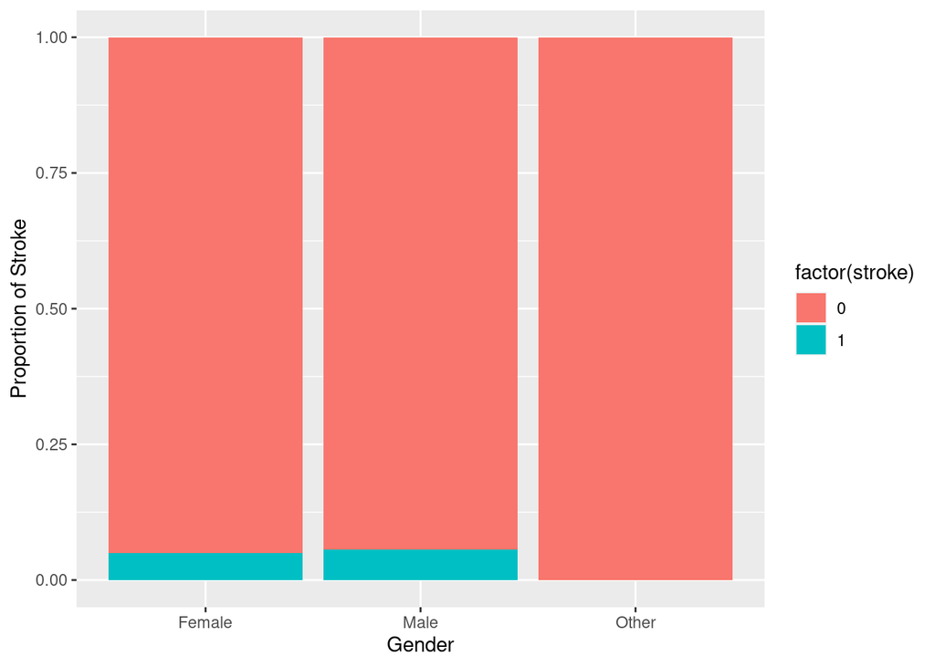

```r
# Visualize the distribution of stroke within each category of the independent variable
ggplot(stroke_data, aes(x = gender, fill = factor(stroke))) +
  geom_bar(position = "fill") +
  labs(x = "Gender", y = "Proportion of Stroke")
```

The Pearson’s chi-squared test was conducted to assess the relationship between gender and stroke in the dataset. The test statistic obtained was X-squared = 0.58334, with 2 degrees of freedom. The corresponding p-value was found to be 0.747.

Since the p-value (0.747) is greater than the significance level (commonly set at 0.05), we fail to reject the null hypothesis. This suggests that there is no significant association between gender and stroke in the dataset.

Since the visualization indicates that the proportion of males and females is similar, it aligns with the results of the Pearson’s chi-squared test, which suggests that gender is not significantly associated with stroke in the dataset.

This consistency between the visualization and statistical test reinforces the conclusion that gender may not be a significant factor influencing the likelihood of experiencing a stroke in the analyzed dataset.

```r
# Assessing the relationship for categorical independent variables:
# Chi-squared test or Fisher's exact test
chi_squared2 <- chisq.test(stroke_data$ever_married, stroke_data$stroke)
chi_squared2
```

```
##
##  Pearson's Chi-squared test with Yates' continuity correction
##
## data:  stroke_data$ever_married and stroke_data$stroke
## X-squared = 16.865, df = 1, p-value = 4.013e-05
```

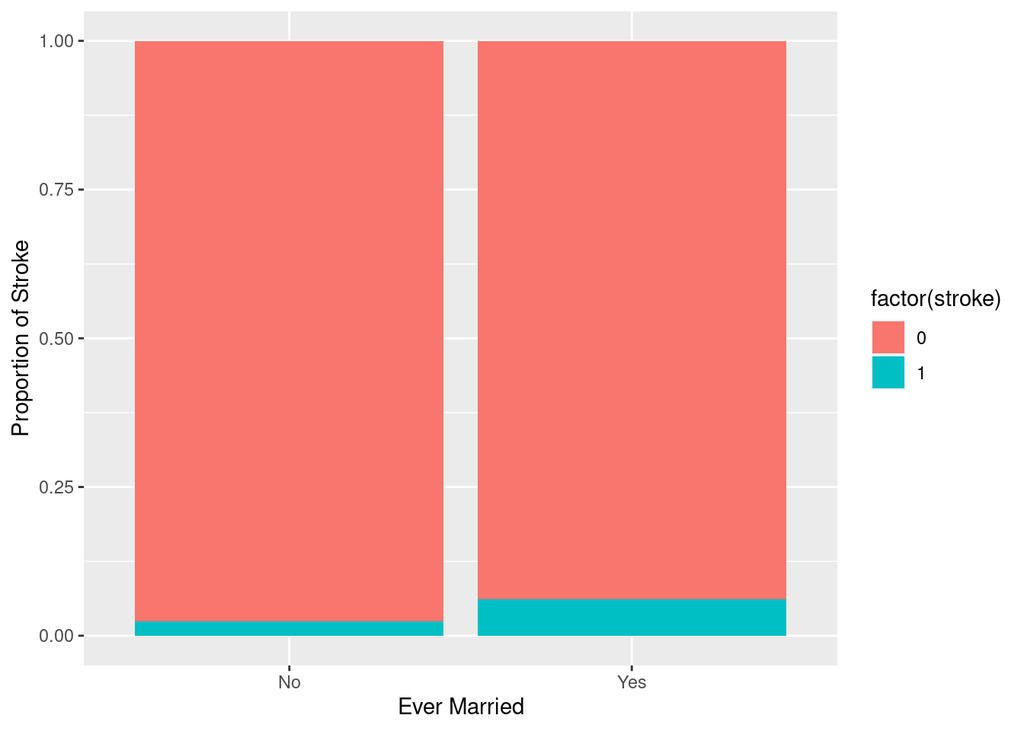

```r
# Visualize the distribution of stroke within each category of the independent variable
ggplot(stroke_data, aes(x = ever_married, fill = factor(stroke))) +
  geom_bar(position = "fill") +
  labs(x = "Ever Married", y = "Proportion of Stroke")
```

The Pearson’s chi-squared test with Yates’ continuity correction was conducted to evaluate the relationship between the marital status (ever_married) and stroke in the dataset. The test yielded a chi-squared statistic of X-squared = 16.865, with 1 degree of freedom, and a corresponding p-value of 4.013e-05.

Since the p-value (4.013e-05) is much less than the significance level (commonly set at 0.05), we reject the null hypothesis. This suggests that there is a significant association between marital status and stroke in the dataset.

The visualization showing a higher proportion of individuals who are “ever married” compared to those who are not aligns with the results of the Pearson’s chi-squared test with Yates’ continuity correction.

The statistical test indicates a significant association between marital status (ever_married) and stroke, with a lower p-value suggesting that the observed difference in proportions is unlikely to have occurred by chance.

This consistency between the visualization and statistical analysis strengthens the conclusion that marital status may indeed be a significant factor influencing the likelihood of experiencing a stroke in the dataset.

```r
# Assessing the relationship for categorical independent variables:
# Chi-squared test or Fisher's exact test
chi_squared3 <- chisq.test(stroke_data$work_type, stroke_data$stroke)
chi_squared3
```

```
##
##  Pearson's Chi-squared test
##
## data:  stroke_data$work_type and stroke_data$stroke
## X-squared = 12.717, df = 4, p-value = 0.01274
```

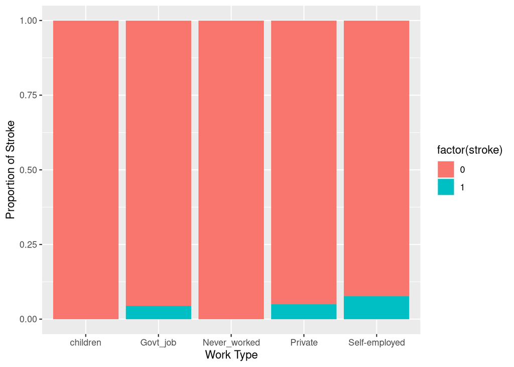

```r
# Visualize the distribution of stroke within each category of the independent variable
ggplot(stroke_data, aes(x = work_type, fill = factor(stroke))) +
  geom_bar(position = "fill") +
  labs(x = "Work Type", y = "Proportion of Stroke")
```

The Pearson’s chi-squared test conducted to assess the relationship between work type and stroke in the dataset yielded a chi-squared statistic of X-squared = 12.717, with 4 degrees of freedom, and a corresponding p-value of 0.01274.

Since the p-value (0.01274) is less than the significance level (commonly set at 0.05), we reject the null hypothesis. This suggests that there is a significant association between work type and stroke in the dataset.

The visualization indicating that the proportion of stroke is highest among individuals who are self-employed aligns with the results of the Pearson’s chi-squared test.

The statistical test suggests a significant association between work type and stroke, with a lower p-value indicating that the observed difference in proportions is unlikely to have occurred by chance.

This consistency between the visualization and statistical analysis strengthens the conclusion that work type may indeed be a significant factor influencing the likelihood of experiencing a stroke in the dataset.

```r
# Assessing the relationship for categorical independent variables:
# Chi-squared test or Fisher's exact test
chi_squared4 <- chisq.test(stroke_data$Residence_type, stroke_data$stroke)
chi_squared4
```

```
##
##  Pearson's Chi-squared test with Yates' continuity correction
##
## data:  stroke_data$Residence_type and stroke_data$stroke
## X-squared = 0.07761, df = 1, p-value = 0.7806
```

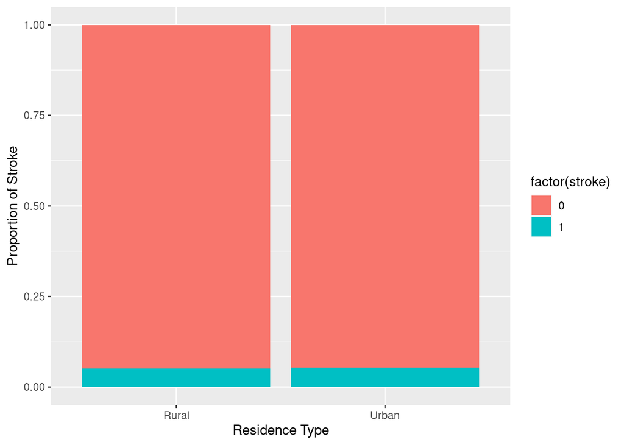

```r
# Visualize the distribution of stroke within each category of the independent variable
ggplot(stroke_data, aes(x = Residence_type, fill = factor(stroke))) +
  geom_bar(position = "fill") +
  labs(x = "Residence Type", y = "Proportion of Stroke")
```

The Pearson’s chi-squared test with Yates’ continuity correction was conducted to evaluate the relationship between residence type (urban or rural) and stroke in the dataset. The test yielded a chi-squared statistic of X-squared = 0.07761, with 1 degree of freedom, and a corresponding p-value of 0.7806.

Since the p-value (0.7806) is greater than the significance level (commonly set at 0.05), we fail to reject the null hypothesis. This suggests that there is no significant association between residence type and stroke in the dataset.

The visualization shows that the proportion of stroke is similar for both urban and rural residence types, it aligns with the results of the Pearson’s chi-squared test.

The statistical test suggests that there is no significant association between residence type (urban or rural) and stroke, which is consistent with the observation that the proportions are similar in the visualization.

This consistency between the visualization and statistical analysis reinforces the conclusion that residence type may not be a significant factor influencing the likelihood of experiencing a stroke in the dataset.

```r
# Assessing the relationship for categorical independent variables:
# Chi-squared test or Fisher's exact test
chi_squared5 <- chisq.test(stroke_data$smoking_status, stroke_data$stroke)
chi_squared5
```

```
##
##  Pearson's Chi-squared test
##
## data:  stroke_data$smoking_status and stroke_data$stroke
## X-squared = 5.9932, df = 2, p-value = 0.04996
```

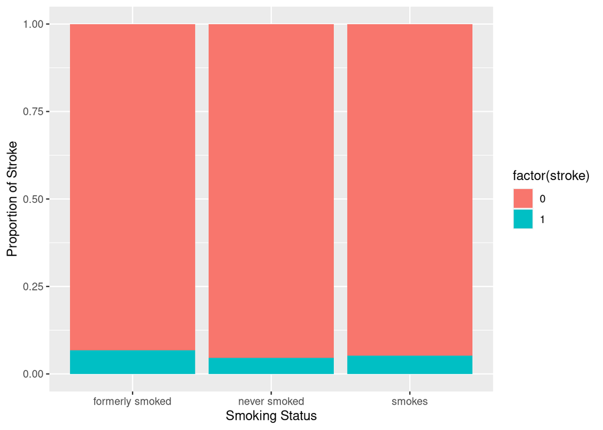

```r
# Visualize the distribution of stroke within each category of the independent variable
ggplot(stroke_data, aes(x = smoking_status, fill = factor(stroke))) +
  geom_bar(position = "fill") +
  labs(x = "Smoking Status", y = "Proportion of Stroke")
```

The Pearson’s chi-squared test was conducted to assess the relationship between smoking status and stroke in the dataset. The test yielded a chi-squared statistic of X-squared = 5.9932, with 2 degrees of freedom, and a corresponding p-value of 0.04996.

Since the p-value (0.04996) is slightly less than the significance level (commonly set at 0.05), we may consider rejecting the null hypothesis. This suggests that there might be a significant association between smoking status and stroke in the dataset.

The visualization indicates that the proportion of stroke is highest among individuals who formerly smoked, it aligns with the results of the Pearson’s chi-squared test.

The statistical test suggests a potential significant association between smoking status and stroke, with a p-value close to the significance level. The observation in the visualization reinforces this finding, indicating that individuals who formerly smoked may have a higher likelihood of experiencing a stroke compared to other smoking statuses.

This consistency between the visualization and statistical analysis suggests that smoking status may indeed be a significant factor influencing the likelihood of stroke in the dataset.

```r
# For numerical independent variables:
# T-test
# Subset the data for individuals with stroke and without stroke
age_with_stroke <- stroke_data$age[stroke_data$stroke == 1]
age_without_stroke <- stroke_data$age[stroke_data$stroke == 0]

# Perform independent t-test
t_test_result1 <- t.test(age_with_stroke, age_without_stroke)

# View the result
t_test_result1
```

```
##
##  Welch Two Sample t-test
##
## data:  age_with_stroke and age_without_stroke
## t = 21.701, df = 230.57, p-value < 2.2e-16
## alternative hypothesis: true difference in means is not equal to 0
## 95 percent confidence interval:
##  18.62597 22.34590
## sample estimates:
## mean of x mean of y
##  68.05556  47.56962
```

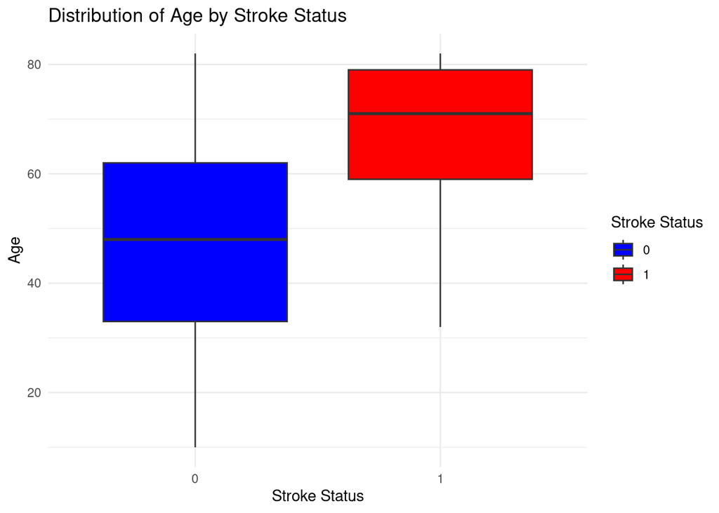

```r
# Create boxplot
ggplot(stroke_data, aes(x = factor(stroke), y = age, fill = factor(stroke))) +
  geom_boxplot() +
  labs(title = "Distribution of Age by Stroke Status",
       x = "Stroke Status",
       y = "Age",
       fill = "Stroke Status") +
  scale_fill_manual(values = c("0" = "blue", "1" = "red")) +
  theme_minimal()
```

The p-value obtained from the Welch Two Sample t-test is highly significant (p < 2.2e-16), indicating a substantial difference in the mean age between individuals with and without stroke. This suggests strong evidence to reject the null hypothesis, indicating that the observed difference in mean age is unlikely to have occurred by random chance alone. Therefore, age appears to be a significant factor associated with the likelihood of experiencing a stroke. Specifically, the significantly higher mean age among individuals with stroke compared to those without stroke suggests that older age may be a risk factor for stroke occurrence.

In summary, the low p-value suggests that age is likely to be an important predictor of stroke incidence, with older individuals being more susceptible to experiencing a stroke.

```r
# For numerical independent variables:
# T-test
# Subset the data for individuals with stroke and without stroke
avg_glucose_level_with_stroke <- stroke_data$avg_glucose_level[stroke_data$stroke == 1]
avg_glucose_level_without_stroke <- stroke_data$avg_glucose_level[stroke_data$stroke == 0]

# Perform independent t-test
t_test_result2 <- t.test(avg_glucose_level_with_stroke, avg_glucose_level_without_stroke)

# View the result
t_test_result2
```

```
##
##  Welch Two Sample t-test
##
## data:  avg_glucose_level_with_stroke and avg_glucose_level_without_stroke
## t = 6.2787, df = 189.74, p-value = 2.272e-09
## alternative hypothesis: true difference in means is not equal to 0
## 95 percent confidence interval:
##  20.59266 39.45885
## sample estimates:
## mean of x mean of y
##  136.7701  106.7444
```

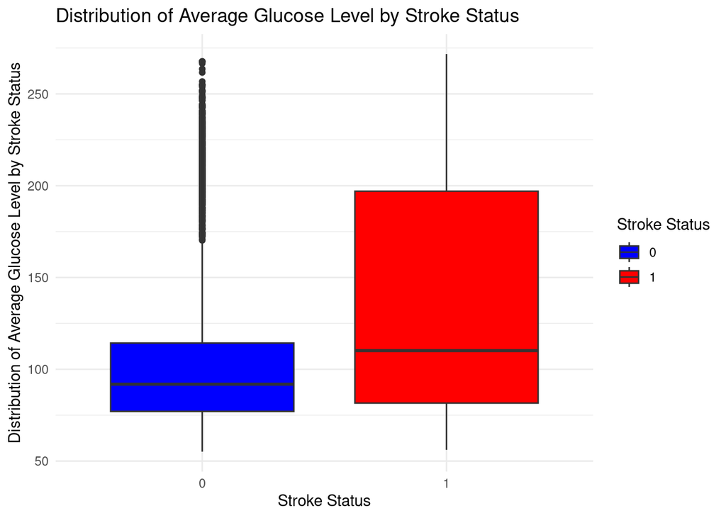

```r
# Create boxplot
ggplot(stroke_data, aes(x = factor(stroke), y = avg_glucose_level, fill = factor(stroke))) +
  geom_boxplot() +
  labs(title = "Distribution of Average Glucose Level by Stroke Status",
       x = "Stroke Status",
       y = "Distribution of Average Glucose Level by Stroke Status",
       fill = "Stroke Status") +
  scale_fill_manual(values = c("0" = "blue", "1" = "red")) +
  theme_minimal()
```

The p-value obtained from the Welch Two Sample t-test is extremely small (p = 2.272e-09), indicating a highly significant difference in the mean glucose levels between individuals with and without stroke. This suggests strong evidence to reject the null hypothesis, indicating that the observed difference in mean glucose levels is unlikely to have occurred by random chance alone. Therefore, glucose level appears to be a significant factor associated with the likelihood of experiencing a stroke.

The 95% confidence interval for the difference in mean glucose levels between the two groups ranges from 20.59 to 39.46 units. This interval suggests that, on average, individuals with stroke have significantly higher glucose levels compared to those without stroke.

The observation from the visualization, showing that individuals with higher glucose levels tend to have a stroke, is consistent with the statistical analysis results. This supports the notion that elevated glucose levels may be a risk factor for stroke incidence.

In summary, the low p-value and the wide confidence interval suggest that glucose level is likely to be an important predictor of stroke incidence, with higher glucose levels being associated with an increased risk of experiencing a stroke.

```r
# For numerical independent variables:
# T-test
# Subset the data for individuals with stroke and without stroke
bmi_with_stroke <- stroke_data$bmi[stroke_data$stroke == 1]
bmi_without_stroke <- stroke_data$bmi[stroke_data$stroke == 0]

# Perform independent t-test
t_test_result3 <- t.test(bmi_with_stroke, bmi_without_stroke)

# View the result
t_test_result3
```

```
##
##  Welch Two Sample t-test
##
## data:  bmi_with_stroke and bmi_without_stroke
## t = 0.78234, df = 206.84, p-value = 0.4349
## alternative hypothesis: true difference in means is not equal to 0
## 95 percent confidence interval:
##  -0.5801417  1.3434874
## sample estimates:
## mean of x mean of y
##  30.65167  30.26999
```

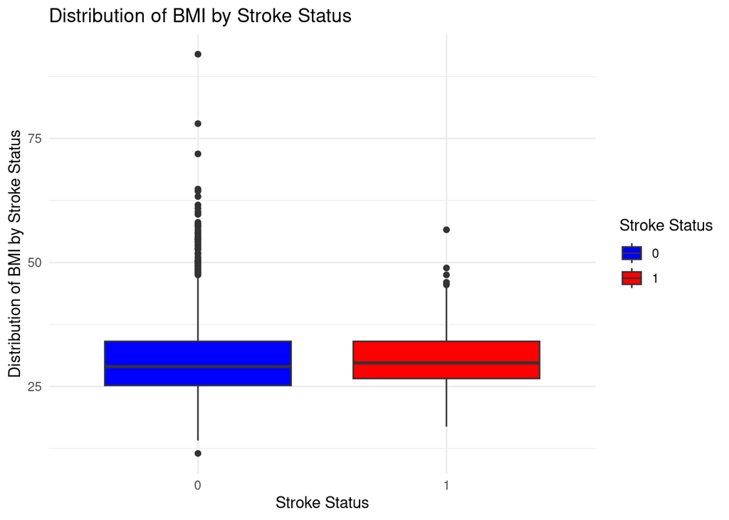

```r
# Create boxplot
ggplot(stroke_data, aes(x = factor(stroke), y = bmi, fill = factor(stroke))) +
  geom_boxplot() +
  labs(title = "Distribution of BMI by Stroke Status",
       x = "Stroke Status",
       y = "Distribution of BMI by Stroke Status",
       fill = "Stroke Status") +
  scale_fill_manual(values = c("0" = "blue", "1" = "red")) +
  theme_minimal()
```

The p-value obtained from the Welch Two Sample t-test for BMI (Body Mass Index) is not significant (p = 0.4349), indicating that there is not a statistically significant difference in the mean BMI between individuals with and without stroke. This suggests that the observed difference in mean BMI is likely to have occurred by random chance alone, and there may not be a strong association between BMI and stroke incidence.

The 95% confidence interval for the difference in mean BMI between the two groups ranges from -0.58 to 1.34 units. This interval includes zero, further indicating that there is no substantial difference in mean BMI between individuals with and without stroke.

The observation from the visualization, showing that there is not much difference in BMI between individuals with and without stroke, aligns with the statistical analysis results.

In summary, based on the p-value and confidence interval, it appears that BMI may not be a significant predictor of stroke incidence in this dataset.

```r
# For binary independent variables:
# Logistic regression
logit_model <- glm(stroke ~ hypertension, data = stroke_data, family = "binomial")
summary(logit_model)
```

```
##
## Call:
## glm(formula = stroke ~ hypertension, family = "binomial", data = stroke_data)
##
## Deviance Residuals:
##     Min       1Q   Median       3Q      Max
## -0.5486  -0.2885  -0.2885  -0.2885   2.5299
##
## Coefficients:
##              Estimate Std. Error z value Pr(>|z|)
## (Intercept)  -3.15856    0.09206 -34.309  < 2e-16 ***
## hypertension  1.34082    0.16991   7.892 2.99e-15 ***
## ---
## Signif. codes:  0 '***' 0.001 '**' 0.01 '*' 0.05 '.' 0.1 ' ' 1
##
## (Dispersion parameter for binomial family taken to be 1)
##
##     Null deviance: 1411.0  on 3425  degrees of freedom
## Residual deviance: 1358.2  on 3424  degrees of freedom
## AIC: 1362.2
##
## Number of Fisher Scoring iterations: 6
```

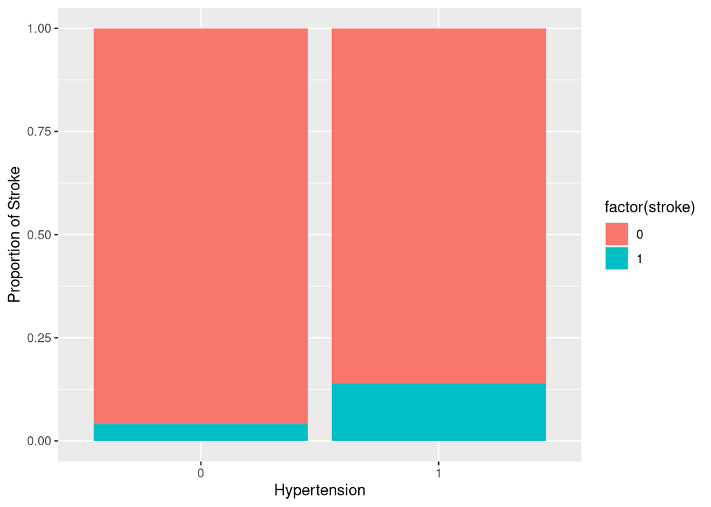

```r
# Visualize the proportion of stroke within each category of the binary independent variable
ggplot(stroke_data, aes(x = factor(hypertension), fill = factor(stroke))) +
  geom_bar(position = "fill") +
  labs(x = "Hypertension", y = "Proportion of Stroke")
```

The logistic regression model predicts stroke occurrence based on hypertension. Hypertension significantly increases the likelihood of stroke (p < 0.001). The model fits well, with hypertension being a strong predictor.

The visual analysis indicates a notable trend: individuals with hypertension are more likely to experience stroke compared to those without hypertension. This observation is supported by the logistic regression model, which found hypertension to be a significant predictor of stroke occurrence. Thus, the visualization reinforces the model’s findings, highlighting the importance of hypertension as a risk factor for stroke.

```r
# For binary independent variables:
# Logistic regression
logit_model <- glm(stroke ~ heart_disease, data = stroke_data, family = "binomial")
summary(logit_model)
```

```
##
## Call:
## glm(formula = stroke ~ heart_disease, family = "binomial", data = stroke_data)
##
## Deviance Residuals:
##     Min       1Q   Median       3Q      Max
## -0.6198  -0.3025  -0.3025  -0.3025   2.4929
##
## Coefficients:
##               Estimate Std. Error z value Pr(>|z|)
## (Intercept)   -3.06157    0.08525  -35.91  < 2e-16 ***
## heart_disease  1.50929    0.20231    7.46 8.62e-14 ***
## ---
## Signif. codes:  0 '***' 0.001 '**' 0.01 '*' 0.05 '.' 0.1 ' ' 1
##
## (Dispersion parameter for binomial family taken to be 1)
##
##     Null deviance: 1411.0  on 3425  degrees of freedom
## Residual deviance: 1367.3  on 3424  degrees of freedom
## AIC: 1371.3
##
## Number of Fisher Scoring iterations: 5
```

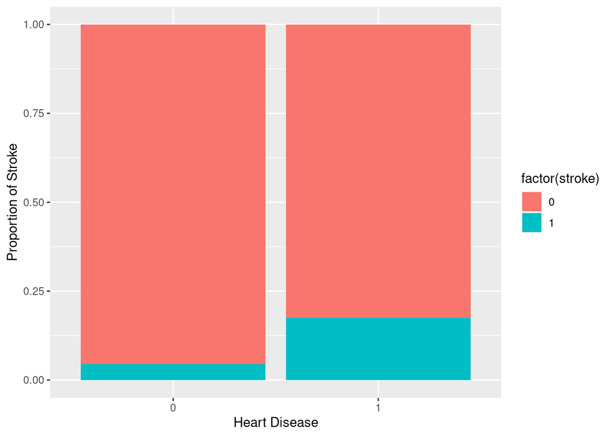

```r
# Visualize the proportion of stroke within each category of the binary independent variable
ggplot(stroke_data, aes(x = factor(heart_disease), fill = factor(stroke))) +
  geom_bar(position = "fill") +
  labs(x = "Heart Disease", y = "Proportion of Stroke")
```

The logistic regression model predicts stroke occurrence based on heart disease. Individuals with heart disease are significantly more likely to experience stroke (p < 0.001), as indicated by the model’s coefficient estimate. Visual examination of the data further supports this finding, revealing a notable association between heart disease and stroke occurrence.

```r
# Perform feature engineering on the bmi and check for association with stroke
# Define BMI categories based on standard thresholds
bmi_categories <- cut(stroke_data$bmi,
                      breaks = c(-Inf, 18.5, 24.9, 29.9, Inf),
                      labels = c("Underweight", "Normal weight", "Overweight", "Obese"),
                      include.lowest = TRUE)

# Add the new BMI categories to the dataset
stroke_data$BMI_Category <- bmi_categories

# Check the distribution of BMI categories
table(stroke_data$BMI_Category)
```

```
##
##   Underweight Normal weight    Overweight         Obese
##            52           744          1093          1537
```

```r
# Check association between BMI categories and stroke
chi_test <- chisq.test(stroke_data$BMI_Category, stroke_data$stroke)
chi_test
```

```
##
##  Pearson's Chi-squared test
##
## data:  stroke_data$BMI_Category and stroke_data$stroke
## X-squared = 5.0618, df = 3, p-value = 0.1673
```

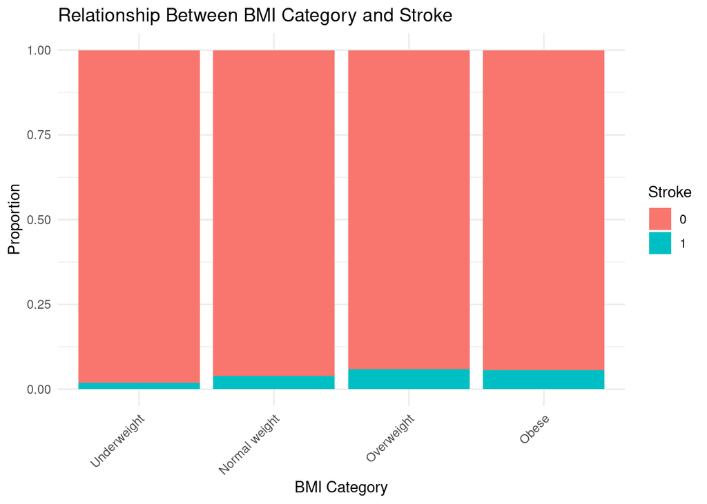

```r
# Create a stacked bar plot
ggplot(stroke_data, aes(x = BMI_Category, fill = factor(stroke))) +
  geom_bar(position = "fill") +
  labs(x = "BMI Category", y = "Proportion", fill = "Stroke") +
  ggtitle("Relationship Between BMI Category and Stroke") +
  theme_minimal() +
  theme(axis.text.x = element_text(angle = 45, hjust = 1))
```

The Pearson’s Chi-squared test results indicate that there is no significant association between BMI categories and stroke (p-value = 0.1673). This suggests that the proportion of stroke cases does not significantly differ across BMI categories.

# Task Two: Build prediction models

```r
# Data Pre-processing
# Drop the ID column
stroke_data <- stroke_data[, -1]  # ID column is the first column

# Convert categorical variables to factors
stroke_data$gender <- factor(stroke_data$gender)
stroke_data$ever_married <- factor(stroke_data$ever_married)
stroke_data$work_type <- factor(stroke_data$work_type)
stroke_data$Residence_type <- factor(stroke_data$Residence_type)
stroke_data$smoking_status <- factor(stroke_data$smoking_status)
stroke_data$stroke <- factor(stroke_data$stroke)
stroke_data$BMI_Category <- factor(stroke_data$BMI_Category)
stroke_data$hypertension <- factor(stroke_data$hypertension)
stroke_data$heart_disease <- factor(stroke_data$heart_disease)

# Standardize numeric variables
numeric_vars1 <- c("age", "avg_glucose_level", "bmi")
stroke_data[numeric_vars1] <- scale(stroke_data[numeric_vars1])

#Split the Data into Train and Test Sets
# use the caret package to split the data into training and testing sets.

#install.packages("caret")
library(caret)

# Set seed for reproducibility
set.seed(123)

# Split the data into train (80%) and test (20%) sets
train_index <- createDataPartition(stroke_data$stroke, p = 0.8, list = FALSE)
train_data <- stroke_data[train_index, ]
test_data <- stroke_data[-train_index, ]

#install.packages("e1071")

library(e1071) # For Naive Bayes


# Train Naive Bayes model
nb_model <- naiveBayes(stroke ~ ., data = train_data)
```

# Task Three: Evaluate and select prediction models

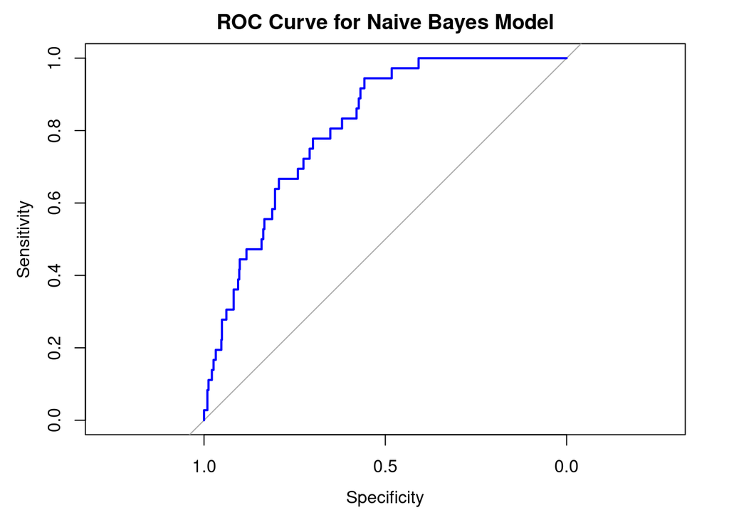

```r
# Evaluate the model
# Install and load the pROC package
# install.packages("pROC")
library(pROC)

# Calculate ROC curve and AUC for Naive Bayes model predictions
nb_pred <- predict(nb_model, newdata = test_data, type = "raw")[, 2]
nb_roc <- roc(test_data$stroke, nb_pred)

# Plot ROC curve
plot(nb_roc, main = "ROC Curve for Naive Bayes Model", col = "blue")
```

```r
# Calculate AUC
nb_auc <- auc(nb_roc)
print(paste("AUC for Naive Bayes Model:", round(nb_auc, 3)))
```

```
## [1] "AUC for Naive Bayes Model: 0.81"
```

An AUC value of 0.81 indicates that the Naive Bayes model has good discriminatory power in distinguishing between positive and negative classes (in this case, individuals who had a stroke and those who did not). Typically, an AUC value above 0.8 is considered very good for a predictive model. It suggests that the model performs well in ranking instances by their likelihood of having a stroke.

```r
# Decision Tree
# Load the rpart package
library(rpart)

# Build the decision tree model
tree_model <- rpart(stroke ~ ., data = train_data, method = "class")

# Make predictions on the test data
tree_pred <- predict(tree_model, newdata = test_data, type = "class")

# Evaluate the model
tree_accuracy <- sum(tree_pred == test_data$stroke) / nrow(test_data)
tree_accuracy
```

```
## [1] 0.9474453
```

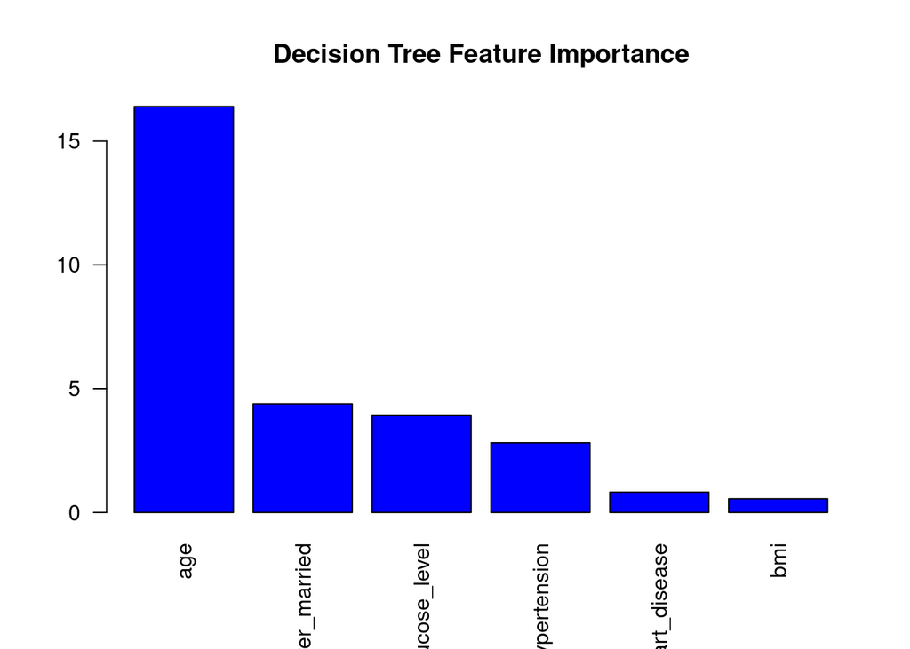

```r
# Visualize feature importance
#install.packages("vip")
library(vip)
# Calculate feature importance
importance <- tree_model$variable.importance

# Plot feature importance
barplot(importance, main = "Decision Tree Feature Importance", col = "blue", las = 2)
```

The decision tree model achieved an accuracy of approximately 94.74% on the test data. This means that the model correctly predicted the stroke status for about 94.74% of the individuals in the test dataset.

From the feature importance visual, age is a significant factor in determining the likelihood of a stroke occurrence.

```r
# Evaluate accuracy
tree_accuracy <- mean(tree_pred == test_data$stroke)
nb_accuracy <- mean(nb_pred == test_data$stroke)

# Compare accuracies
if (tree_accuracy > nb_accuracy) {
  print("Decision Tree has higher accuracy.")
} else if (tree_accuracy < nb_accuracy) {
  print("Naive Bayes has higher accuracy.")
} else {
  print("Both models have the same accuracy.")
}
```

```
## [1] "Decision Tree has higher accuracy."
```

# Findings and conclusions of stroke prediction analysis:

Overall, the analysis provided valuable insights into stroke prediction and demonstrated the potential of machine learning models in healthcare decision-making.